# Coursera Statistical Inference Part 1

Stella

2022-12-09

## Project Summary

This is part one to the two part projects (1. A simulation excercise, 2. Basic inferential data analysis). Here, I will investigate the exponential distribution in R and compare it to the Central Limit Theorem. The mean and standard deviation of the exponential distribution is 1/lambda. Lambda will be set to 0.2 for all simulations, and there will be 1000 simulations. I will also determine the distribution of averages for 40 exponentials.

## Simulations

Set the seed, the rate parameter, the number of exponentials, and the number of simulations based on the rubric:

simulate the 40 exponentials, then calculate the mean.

## Answering Question 1

Calculate and compare the sample mean to the theoretical mean.

```
## [1] 4.974239
```

```
## [1] 5
```

Develop a histogram of the simulated exponential sample means. The red indicates the sample mean while the blue indicates the theoretical mean.

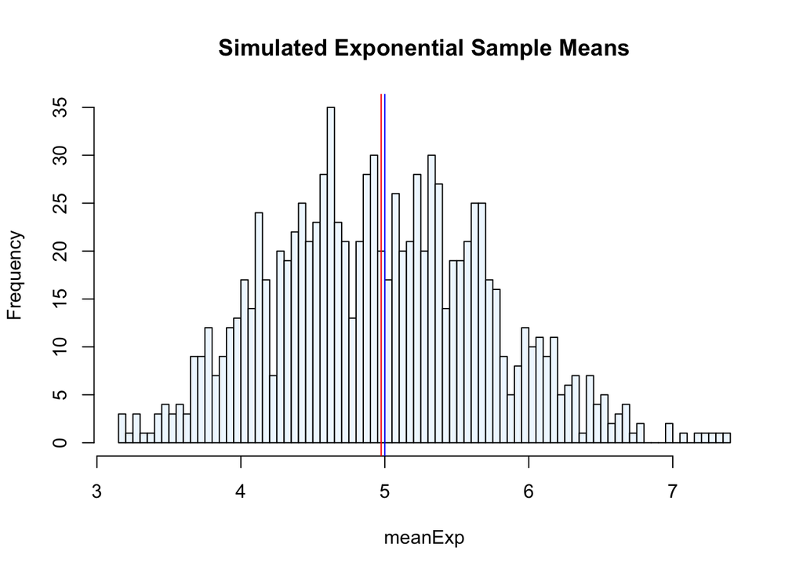

Based on the graph, the sample mean is very close to the theoretical mean.

## Answering Question 2

Calculate and compare the sample variance to the theoretical variace.

```
## [1] 0.5706551
```

```
## [1] 0.625
```

The sample variance is equal to 0.571 which is very close to the theoretical variance of 0.625.

## Answering Question 3

Investigate whether the exponential distribution is approximately normal. Based on CLT, the mean should be relatively normal.

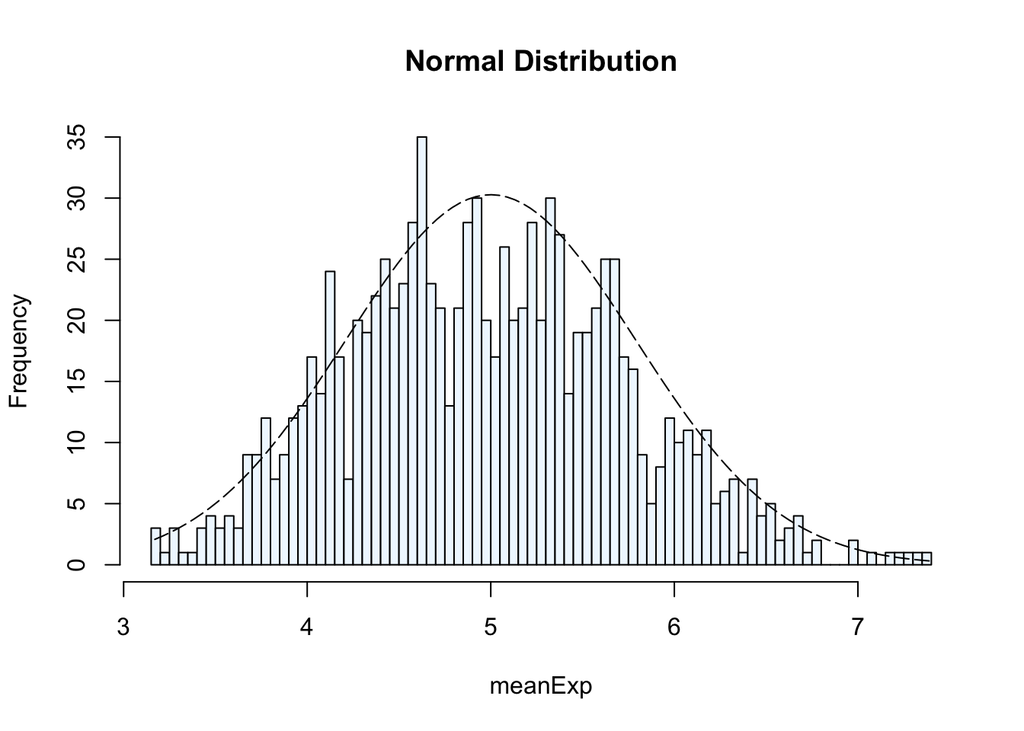

Based on the figure, the distribution of means follows a normal curve relatively closely. If there were to be more trials (>1000) the curve would likely be closer to a normal distribution.